# Assignment: Prediction Assignment Writeup

Antonio Maurandi López

21 de junio de 2016

Using devices such as *Jawbone Up*, *Nike FuelBand*, and *Fitbit* it is now possible to collect a large amount of data about personal activity relatively inexpensively. Our goal is to predict the manner in which they did the exercise. This is the “classe” variable in the training set. We will use data data from accelerometers on the belt, forearm, arm, and dumbell of 6 participants to predict the “classe” variable.

# Loading and processing the data

Exploration of the data.

```r
# download data from the source url
filepath     <- "XXXXX"
filepath     <- "pml-training.csv"
train <- read.table(filepath,  sep="," , header=T, dec=".")
filepath     <- "XXX"
filepath     <- "pml-testing.csv"
test <- read.table(filepath,  sep="," , header=T, dec=".")
```

## Missing values: `NA`

There are variables with a lot of `NA` values, we will use only those variables which are not `NA` always, let set the criteria at 80% of data available, not `NA`.

```r
n         <- nrow(train)
f.numofna <- function (vector){
    return( sum(is.na (vector)))
}

x       <- as.vector(apply(train, 2, f.numofna)/n)
pander(table(x), caption = "Number of variables with a percentaje of missiing values: `0%` or `97%`")
```

Number of variables with a percentaje of missiing values: `0%` or `97%`

| 0 | 0.979308938946081 |
| --- | --- |
| 93 | 67 |

```r
varsnona <- (x<0.8)

n1    <- length(names(train) )
train <- train[ ,varsnona ]
test  <- test[  ,varsnona ]

# kk<-lapply(train,data.class)
# pander(kk)
n2 <- length( names(train) )
```

We will keep 93 variables instead of the original 160 variables.

## Outcome variable `classe`

It is interesting to check if there are any class more presnet tahn others

```r
tt<-table(train$classe)
pander::pander( tt
                ,caption="absolute frecuency of classes of variebl classe" )
```

absolute frecuency of classes of variebl classe

| A | B | C | D | E |
| --- | --- | --- | --- | --- |
| 5580 | 3797 | 3422 | 3216 | 3607 |

```r
tt<- prop.table(tt)*100
pander::pander(tt
               , caption="percentage table" )
```

percentage table

| A | B | C | D | E |
| --- | --- | --- | --- | --- |
| 28.44 | 19.35 | 17.44 | 16.39 | 18.38 |

We can see that there are 5 different clasifications and that all of them are arround 16% and 29% of the total data available.

```r
pander(numSummary( train )[ ,-c(7:17)]
       , caption="Preliminary descriptives of numerical variables in the trainning dataset.")
```

Preliminary descriptives of numerical variables in the trainning dataset.

|  | n | mean | sd | median | max | min |
| --- | --- | --- | --- | --- | --- | --- |
| **X** | 19622 | 9812 | 5665 | 9812 | 19622 | 1 |
| **raw_timestamp_part_1** | 19622 | 1322827119 | 204928 | 1322832920 | 1323095081 | 1322489605 |
| **raw_timestamp_part_2** | 19622 | 500656 | 288223 | 496380 | 998801 | 294 |
| **num_window** | 19622 | 430.6 | 247.9 | 424 | 864 | 1 |
| **roll_belt** | 19622 | 64.41 | 62.75 | 113 | 162 | -28.9 |
| **pitch_belt** | 19622 | 0.3053 | 22.35 | 5.28 | 60.3 | -55.8 |
| **yaw_belt** | 19622 | -11.21 | 95.19 | -13 | 179 | -180 |
| **total_accel_belt** | 19622 | 11.31 | 7.742 | 17 | 29 | 0 |
| **gyros_belt_x** | 19622 | -0.005592 | 0.2073 | 0.03 | 2.22 | -1.04 |
| **gyros_belt_y** | 19622 | 0.03959 | 0.07824 | 0.02 | 0.64 | -0.64 |
| **gyros_belt_z** | 19622 | -0.1305 | 0.2413 | -0.1 | 1.62 | -1.46 |
| **accel_belt_x** | 19622 | -5.595 | 29.64 | -15 | 85 | -120 |
| **accel_belt_y** | 19622 | 30.15 | 28.58 | 35 | 164 | -69 |
| **accel_belt_z** | 19622 | -72.59 | 100.4 | -152 | 105 | -275 |
| **magnet_belt_x** | 19622 | 55.6 | 64.18 | 35 | 485 | -52 |
| **magnet_belt_y** | 19622 | 593.7 | 35.68 | 601 | 673 | 354 |
| **magnet_belt_z** | 19622 | -345.5 | 65.21 | -320 | 293 | -623 |
| **roll_arm** | 19622 | 17.83 | 72.74 | 0 | 180 | -180 |
| **pitch_arm** | 19622 | -4.612 | 30.68 | 0 | 88.5 | -88.8 |
| **yaw_arm** | 19622 | -0.6188 | 71.36 | 0 | 180 | -180 |
| **total_accel_arm** | 19622 | 25.51 | 10.52 | 27 | 66 | 1 |
| **gyros_arm_x** | 19622 | 0.04277 | 1.994 | 0.08 | 4.87 | -6.37 |
| **gyros_arm_y** | 19622 | -0.2571 | 0.8514 | -0.24 | 2.84 | -3.44 |
| **gyros_arm_z** | 19622 | 0.2695 | 0.5532 | 0.23 | 3.02 | -2.33 |
| **accel_arm_x** | 19622 | -60.24 | 182 | -44 | 437 | -404 |
| **accel_arm_y** | 19622 | 32.6 | 109.9 | 14 | 308 | -318 |
| **accel_arm_z** | 19622 | -71.25 | 134.7 | -47 | 292 | -636 |
| **magnet_arm_x** | 19622 | 191.7 | 443.6 | 289 | 782 | -584 |
| **magnet_arm_y** | 19622 | 156.6 | 201.9 | 202 | 583 | -392 |
| **magnet_arm_z** | 19622 | 306.5 | 326.6 | 444 | 694 | -597 |
| **roll_dumbbell** | 19622 | 23.84 | 69.93 | 48.17 | 153.5 | -153.7 |
| **pitch_dumbbell** | 19622 | -10.78 | 36.99 | -20.96 | 149.4 | -149.6 |
| **yaw_dumbbell** | 19622 | 1.674 | 82.52 | -3.324 | 155 | -150.9 |
| **total_accel_dumbbell** | 19622 | 13.72 | 10.23 | 10 | 58 | 0 |
| **gyros_dumbbell_x** | 19622 | 0.1611 | 1.509 | 0.13 | 2.22 | -204 |
| **gyros_dumbbell_y** | 19622 | 0.04606 | 0.61 | 0.03 | 52 | -2.1 |
| **gyros_dumbbell_z** | 19622 | -0.129 | 2.287 | -0.13 | 317 | -2.38 |
| **accel_dumbbell_x** | 19622 | -28.62 | 67.32 | -8 | 235 | -419 |
| **accel_dumbbell_y** | 19622 | 52.63 | 80.75 | 41.5 | 315 | -189 |
| **accel_dumbbell_z** | 19622 | -38.32 | 109.5 | -1 | 318 | -334 |
| **magnet_dumbbell_x** | 19622 | -328.5 | 339.7 | -479 | 592 | -643 |
| **magnet_dumbbell_y** | 19622 | 221 | 326.9 | 311 | 633 | -3600 |
| **magnet_dumbbell_z** | 19622 | 46.05 | 140 | 13 | 452 | -262 |
| **roll_forearm** | 19622 | 33.83 | 108 | 21.7 | 180 | -180 |
| **pitch_forearm** | 19622 | 10.71 | 28.15 | 9.24 | 89.8 | -72.5 |
| **yaw_forearm** | 19622 | 19.21 | 103.2 | 0 | 180 | -180 |
| **total_accel_forearm** | 19622 | 34.72 | 10.06 | 36 | 108 | 0 |
| **gyros_forearm_x** | 19622 | 0.158 | 0.6486 | 0.05 | 3.97 | -22 |
| **gyros_forearm_y** | 19622 | 0.07517 | 3.101 | 0.03 | 311 | -7.02 |
| **gyros_forearm_z** | 19622 | 0.1512 | 1.754 | 0.08 | 231 | -8.09 |
| **accel_forearm_x** | 19622 | -61.65 | 180.6 | -57 | 477 | -498 |
| **accel_forearm_y** | 19622 | 163.7 | 200.1 | 201 | 923 | -632 |
| **accel_forearm_z** | 19622 | -55.29 | 138.4 | -39 | 291 | -446 |
| **magnet_forearm_x** | 19622 | -312.6 | 347 | -378 | 672 | -1280 |
| **magnet_forearm_y** | 19622 | 380.1 | 509.4 | 591 | 1480 | -896 |
| **magnet_forearm_z** | 19622 | 393.6 | 369.3 | 511 | 1090 | -973 |

```r
pander( charSummary(train)
        , caption="Preliminary descriptives of non numerical variables in the trainning dataset.")
```

Preliminary descriptives of non numerical variables in the trainning dataset.

|  | n | miss | miss% | unique |
| --- | --- | --- | --- | --- |
| **user_name** | 19622 | 0 | 0 | 6 |
| **cvtd_timestamp** | 19622 | 0 | 0 | 20 |
| **new_window** | 19622 | 0 | 0 | 2 |
| **kurtosis_roll_belt** | 19622 | 0 | 0 | 397 |
| **kurtosis_picth_belt** | 19622 | 0 | 0 | 317 |
| **kurtosis_yaw_belt** | 19622 | 0 | 0 | 2 |
| **skewness_roll_belt** | 19622 | 0 | 0 | 395 |
| **skewness_roll_belt.1** | 19622 | 0 | 0 | 338 |
| **skewness_yaw_belt** | 19622 | 0 | 0 | 2 |
| **max_yaw_belt** | 19622 | 0 | 0 | 68 |
| **min_yaw_belt** | 19622 | 0 | 0 | 68 |
| **amplitude_yaw_belt** | 19622 | 0 | 0 | 4 |
| **kurtosis_roll_arm** | 19622 | 0 | 0 | 330 |
| **kurtosis_picth_arm** | 19622 | 0 | 0 | 328 |
| **kurtosis_yaw_arm** | 19622 | 0 | 0 | 395 |
| **skewness_roll_arm** | 19622 | 0 | 0 | 331 |
| **skewness_pitch_arm** | 19622 | 0 | 0 | 328 |
| **skewness_yaw_arm** | 19622 | 0 | 0 | 395 |
| **kurtosis_roll_dumbbell** | 19622 | 0 | 0 | 398 |
| **kurtosis_picth_dumbbell** | 19622 | 0 | 0 | 401 |
| **kurtosis_yaw_dumbbell** | 19622 | 0 | 0 | 2 |
| **skewness_roll_dumbbell** | 19622 | 0 | 0 | 401 |
| **skewness_pitch_dumbbell** | 19622 | 0 | 0 | 402 |
| **skewness_yaw_dumbbell** | 19622 | 0 | 0 | 2 |
| **max_yaw_dumbbell** | 19622 | 0 | 0 | 73 |
| **min_yaw_dumbbell** | 19622 | 0 | 0 | 73 |
| **amplitude_yaw_dumbbell** | 19622 | 0 | 0 | 3 |
| **kurtosis_roll_forearm** | 19622 | 0 | 0 | 322 |
| **kurtosis_picth_forearm** | 19622 | 0 | 0 | 323 |
| **kurtosis_yaw_forearm** | 19622 | 0 | 0 | 2 |
| **skewness_roll_forearm** | 19622 | 0 | 0 | 323 |
| **skewness_pitch_forearm** | 19622 | 0 | 0 | 319 |
| **skewness_yaw_forearm** | 19622 | 0 | 0 | 2 |
| **max_yaw_forearm** | 19622 | 0 | 0 | 45 |
| **min_yaw_forearm** | 19622 | 0 | 0 | 45 |
| **amplitude_yaw_forearm** | 19622 | 0 | 0 | 3 |
| **classe** | 19622 | 0 | 0 | 5 |

## Standaritation

It’s interestilng to *scale* and *center* the data it to get models less influenced by the diferent scale of the predictor variables.

```r
procValues <- preProcess( train, method = c("center", "scale") )
trainN     <- predict( procValues, train )
testN      <- predict( procValues, test )
```

We will work with the data set witout the classification variable `classe`.

```r
trainN <- trainN[ ,-c(1:2) ] # delete the id var and username
testN  <- testN[  ,-c(1:2) ]


myclasse     <- trainN$classe  # classification/outcome variable
trainN       <- subset(trainN, select = -c(classe) )
testN        <- subset(testN , select = -c(problem_id) )
```

There are varibles thar are not of the same type (class) in both datasets

```r
# problema con las classes de las variables aml! 20160621
k1 <- sapply( trainN, class)
k2 <- sapply( testN, class )
kk <- data.frame( k1, k2, k0 = NA , stringsAsFactors = FALSE )
# str(kk)
# head(kk)
for (i in 1: nrow(kk)){
    if (kk$k1[i]==kk$k2[i]) { kk$k0[i] <- TRUE }
    else{ kk$k0[i]<- FALSE}
}
length(rownames(kk))
```

[1] 90

```r
# rownames(kk)[kk$k0]
# there are variaboles thar are not of the same type (class) in both datasets
pander(kk[kk$k0==FALSE,1:2], caption="Variables in datasets thar are not of the same data class.")
```

Variables in datasets thar are not of the same data class.

|  | k1 | k2 |
| --- | --- | --- |
| **kurtosis_roll_belt** | factor | logical |
| **kurtosis_picth_belt** | factor | logical |
| **kurtosis_yaw_belt** | factor | logical |
| **skewness_roll_belt** | factor | logical |
| **skewness_roll_belt.1** | factor | logical |
| **skewness_yaw_belt** | factor | logical |
| **max_yaw_belt** | factor | logical |
| **min_yaw_belt** | factor | logical |
| **amplitude_yaw_belt** | factor | logical |
| **kurtosis_roll_arm** | factor | logical |
| **kurtosis_picth_arm** | factor | logical |
| **kurtosis_yaw_arm** | factor | logical |
| **skewness_roll_arm** | factor | logical |
| **skewness_pitch_arm** | factor | logical |
| **skewness_yaw_arm** | factor | logical |
| **kurtosis_roll_dumbbell** | factor | logical |
| **kurtosis_picth_dumbbell** | factor | logical |
| **kurtosis_yaw_dumbbell** | factor | logical |
| **skewness_roll_dumbbell** | factor | logical |
| **skewness_pitch_dumbbell** | factor | logical |
| **skewness_yaw_dumbbell** | factor | logical |
| **max_yaw_dumbbell** | factor | logical |
| **min_yaw_dumbbell** | factor | logical |
| **amplitude_yaw_dumbbell** | factor | logical |
| **kurtosis_roll_forearm** | factor | logical |
| **kurtosis_picth_forearm** | factor | logical |
| **kurtosis_yaw_forearm** | factor | logical |
| **skewness_roll_forearm** | factor | logical |
| **skewness_pitch_forearm** | factor | logical |
| **skewness_yaw_forearm** | factor | logical |
| **max_yaw_forearm** | factor | logical |
| **min_yaw_forearm** | factor | logical |
| **amplitude_yaw_forearm** | factor | logical |

```r
vasrthatareidenticalinclass <- rownames(kk)[kk$k0]  # in boyh dataframes
trainN <- trainN [ ,kk$k0]
trainN       <- subset(trainN, select = vasrthatareidenticalinclass)
testN        <- subset(testN , select = vasrthatareidenticalinclass)
```

We will work only with those variables that have the same class in both datasets: raw_timestamp_part_1, raw_timestamp_part_2, cvtd_timestamp, new_window, num_window, roll_belt, pitch_belt, yaw_belt, total_accel_belt, gyros_belt_x, gyros_belt_y, gyros_belt_z, accel_belt_x, accel_belt_y, accel_belt_z, magnet_belt_x, magnet_belt_y, magnet_belt_z, roll_arm, pitch_arm, yaw_arm, total_accel_arm, gyros_arm_x, gyros_arm_y, gyros_arm_z, accel_arm_x, accel_arm_y, accel_arm_z, magnet_arm_x, magnet_arm_y, magnet_arm_z, roll_dumbbell, pitch_dumbbell, yaw_dumbbell, total_accel_dumbbell, gyros_dumbbell_x, gyros_dumbbell_y, gyros_dumbbell_z, accel_dumbbell_x, accel_dumbbell_y, accel_dumbbell_z, magnet_dumbbell_x, magnet_dumbbell_y, magnet_dumbbell_z, roll_forearm, pitch_forearm, yaw_forearm, total_accel_forearm, gyros_forearm_x, gyros_forearm_y, gyros_forearm_z, accel_forearm_x, accel_forearm_y, accel_forearm_z, magnet_forearm_x, magnet_forearm_y, magnet_forearm_z.

Still there are two variables with typoe `factor`: cvtd_timestamp, new_window. We will delete them because diferences in number of levels and `NA` valyues are usually a problem for random forest.

```r
# qitamos los factores
names(trainN[,sapply(trainN,is.factor)])
```

[1] “cvtd_timestamp” “new_window”

```r
names(testN[,sapply(testN,is.factor)])
```

[1] “cvtd_timestamp” “new_window”

```r
# trainN <- trainN[,-c(sapply(trainN,is.factor))]
# testN <- testN[,-c(sapply(testN,is.factor))]

 trainN <- trainN[ ,-c(3:4) ]
 testN  <- testN[  ,-c(3:4) ]
```

Now we have a trainning data set with 55 variables and 19622 observations.

- **Variables in the model**: *raw_timestamp_part_1, raw_timestamp_part_2, num_window, roll_belt, pitch_belt, yaw_belt, total_accel_belt, gyros_belt_x, gyros_belt_y, gyros_belt_z, accel_belt_x, accel_belt_y, accel_belt_z, magnet_belt_x, magnet_belt_y, magnet_belt_z, roll_arm, pitch_arm, yaw_arm, total_accel_arm, gyros_arm_x, gyros_arm_y, gyros_arm_z, accel_arm_x, accel_arm_y, accel_arm_z, magnet_arm_x, magnet_arm_y, magnet_arm_z, roll_dumbbell, pitch_dumbbell, yaw_dumbbell, total_accel_dumbbell, gyros_dumbbell_x, gyros_dumbbell_y, gyros_dumbbell_z, accel_dumbbell_x, accel_dumbbell_y, accel_dumbbell_z, magnet_dumbbell_x, magnet_dumbbell_y, magnet_dumbbell_z, roll_forearm, pitch_forearm, yaw_forearm, total_accel_forearm, gyros_forearm_x, gyros_forearm_y, gyros_forearm_z, accel_forearm_x, accel_forearm_y, accel_forearm_z, magnet_forearm_x, magnet_forearm_y, magnet_forearm_z*.

# Fit a Model

## Cross validation

We will use a 60% training set, 40% prove set of the total data set with clsification (`classe`).

```r
set.seed( pi )
casostest1  <- createDataPartition( myclasse, p=0.6, list = FALSE )

train1      <- trainN [ casostest1, ]  # trainning data set
train2      <- trainN [-casostest1, ] # proving data set
```

We will use to build a model a trainning data set of 11776 observations that is the 60% of the data in the origibal trainning dataset. We will test the model in a test data set of 7846 that is the remaining 40% of the data of the originla trainning dataset.

We will use the function `randomForest()` from `randomForest` package to fit the model.

```r
# library( "randomForest" )
#  This function can not work with `factor` variables thar have more than 54 levels
# , so we will limitate the factor to have no mor than 10 levels
# , using an _ad hoc_ function `flevels()`.
# so we create a function to select only those fcator variables
# with less than a certain numeber (nl) of levels
# mynl <- 9
# flevels <- function(v, nl = mynl ){
#     if (nlevels(v)< nl) return (TRUE)
#     else return(FALSE)
# }
system.time(
     rfo2 <- randomForest( myclasse[casostest1] ~. , data = train1
    # rfo2 <- randomForest( myclasse[casostest1] ~. , data = train1[,sapply(train1, flevels)]
                     # , mtry = 7  # el default es raiz(p)/3, donde p es el num de vars
                     # , subset = train
                     , importance = TRUE )
    )
```

user system elapsed 54.572 0.096 54.684

```r
# varsinmodel <- names( train1[,sapply(train1, flevels)] )
```

```r
pander( importance( rfo2 ) )
```

Table continues below

|  | A | B | C | D | E | MeanDecreaseAccuracy |
| --- | --- | --- | --- | --- | --- | --- |
| **raw_timestamp_part_1** | 50.48 | 55.66 | 58.21 | 61.13 | 40.81 | 73.94 |
| **raw_timestamp_part_2** | 9.755 | 9.758 | 9.134 | 7.915 | 7.731 | 18.4 |
| **num_window** | 28.95 | 37.23 | 44.09 | 36.21 | 34.17 | 41.49 |
| **roll_belt** | 31.47 | 40.42 | 35.44 | 39.81 | 35.37 | 45.5 |
| **pitch_belt** | 24.54 | 35.23 | 30.03 | 28.86 | 27.02 | 38.1 |
| **yaw_belt** | 31.23 | 33.97 | 31.8 | 38.06 | 27.01 | 46.59 |
| **total_accel_belt** | 13.58 | 14.26 | 12.43 | 13.78 | 15.22 | 16.07 |
| **gyros_belt_x** | 12.62 | 13.8 | 15.8 | 11.04 | 13.45 | 19.44 |
| **gyros_belt_y** | 9.607 | 12.96 | 13.58 | 12.83 | 14.38 | 16.72 |
| **gyros_belt_z** | 16.09 | 21.29 | 20.3 | 18.56 | 20.21 | 23.24 |
| **accel_belt_x** | 12.73 | 16.34 | 15.72 | 13.81 | 13.29 | 18.67 |
| **accel_belt_y** | 10.36 | 12.05 | 11.51 | 14.22 | 12.34 | 14.24 |
| **accel_belt_z** | 17.06 | 22.3 | 20.34 | 19.52 | 19.06 | 23.57 |
| **magnet_belt_x** | 13.7 | 21.26 | 20.4 | 17.45 | 20.19 | 25.13 |
| **magnet_belt_y** | 19.51 | 22.94 | 23.09 | 23.89 | 21.3 | 26.45 |
| **magnet_belt_z** | 18.5 | 21.85 | 20.94 | 24.89 | 20.19 | 25.36 |
| **roll_arm** | 16.68 | 24.61 | 22.39 | 22.87 | 19.51 | 27.06 |
| **pitch_arm** | 12.33 | 20.63 | 15.44 | 15.21 | 14.11 | 20.01 |
| **yaw_arm** | 16.57 | 19.56 | 19.17 | 20.58 | 16.94 | 22.96 |
| **total_accel_arm** | 8.42 | 19.12 | 15.89 | 16.01 | 13.71 | 21.34 |
| **gyros_arm_x** | 12.28 | 17.29 | 12.6 | 16.71 | 15.25 | 18.34 |
| **gyros_arm_y** | 11.74 | 21.88 | 18.37 | 19.48 | 16.94 | 26.09 |
| **gyros_arm_z** | 10.37 | 14.07 | 10.28 | 13.16 | 11.85 | 21.75 |
| **accel_arm_x** | 12.8 | 14.75 | 14.18 | 17.05 | 12.82 | 15.55 |
| **accel_arm_y** | 13.38 | 17.02 | 14.1 | 16.34 | 14.81 | 21.52 |
| **accel_arm_z** | 10.01 | 14.16 | 15.62 | 15.5 | 11.49 | 15.57 |
| **magnet_arm_x** | 15.43 | 15.04 | 17.16 | 16.44 | 13.97 | 16.99 |
| **magnet_arm_y** | 12.15 | 15.57 | 17.02 | 17.85 | 12.88 | 16.23 |
| **magnet_arm_z** | 15.05 | 21.12 | 17.45 | 16.46 | 15.97 | 22.2 |
| **roll_dumbbell** | 20.53 | 24.48 | 25.24 | 25.36 | 23.37 | 28.01 |
| **pitch_dumbbell** | 10.5 | 17.94 | 14.81 | 12.8 | 13.38 | 15.73 |
| **yaw_dumbbell** | 15.79 | 19.34 | 20.46 | 19.18 | 20.52 | 23.29 |
| **total_accel_dumbbell** | 15.4 | 19.76 | 18.74 | 20.25 | 18.83 | 22.69 |
| **gyros_dumbbell_x** | 13.49 | 18.46 | 17.46 | 15.41 | 15.47 | 27.32 |
| **gyros_dumbbell_y** | 15.81 | 17.45 | 21.15 | 17.16 | 15.61 | 19.66 |
| **gyros_dumbbell_z** | 13.86 | 19.67 | 12.98 | 14.62 | 11.09 | 28.99 |
| **accel_dumbbell_x** | 16.23 | 22.24 | 18.73 | 17.95 | 19.38 | 23.18 |
| **accel_dumbbell_y** | 21.78 | 23.24 | 25.88 | 23.81 | 22.99 | 28.72 |
| **accel_dumbbell_z** | 16.47 | 21.62 | 22.61 | 21.46 | 22.58 | 25.49 |
| **magnet_dumbbell_x** | 20.08 | 21.86 | 23.87 | 22.71 | 20.67 | 23.63 |
| **magnet_dumbbell_y** | 25.53 | 31.98 | 35.21 | 30.1 | 25.82 | 34.41 |
| **magnet_dumbbell_z** | 36.55 | 30.84 | 36.36 | 31.24 | 30.31 | 38.98 |
| **roll_forearm** | 23.42 | 20.69 | 25.51 | 18.86 | 19.81 | 23.56 |
| **pitch_forearm** | 25.62 | 28.5 | 32.69 | 29.35 | 27.43 | 34.11 |
| **yaw_forearm** | 13.54 | 16.25 | 15.47 | 16.59 | 15.03 | 19.98 |
| **total_accel_forearm** | 14.21 | 15.37 | 16.01 | 12.72 | 15.43 | 19.9 |
| **gyros_forearm_x** | 9.025 | 13.86 | 14.26 | 12.9 | 13 | 22.44 |
| **gyros_forearm_y** | 11.22 | 19.28 | 17.99 | 15.9 | 15.58 | 22.87 |
| **gyros_forearm_z** | 9.701 | 18.26 | 16.87 | 13.43 | 12.07 | 25.18 |
| **accel_forearm_x** | 15.38 | 21.28 | 19.62 | 24.03 | 20.21 | 22.62 |
| **accel_forearm_y** | 14.46 | 17.18 | 17.39 | 15.92 | 17.22 | 21.3 |
| **accel_forearm_z** | 12.69 | 15.43 | 18.48 | 16.39 | 15.78 | 19.2 |
| **magnet_forearm_x** | 12.74 | 17.22 | 16.22 | 15.44 | 17.08 | 18.84 |
| **magnet_forearm_y** | 14.53 | 17.17 | 17.02 | 16.26 | 16.33 | 19.67 |
| **magnet_forearm_z** | 16.72 | 21.06 | 18.98 | 20.4 | 19.46 | 25.25 |

|  | MeanDecreaseGini |
| --- | --- |
| **raw_timestamp_part_1** | 1113 |
| **raw_timestamp_part_2** | 13.11 |
| **num_window** | 671.1 |
| **roll_belt** | 624.1 |
| **pitch_belt** | 343 |
| **yaw_belt** | 420.7 |
| **total_accel_belt** | 127.1 |
| **gyros_belt_x** | 43.5 |
| **gyros_belt_y** | 53.34 |
| **gyros_belt_z** | 139.2 |
| **accel_belt_x** | 64.63 |
| **accel_belt_y** | 74.77 |
| **accel_belt_z** | 224.8 |
| **magnet_belt_x** | 117.1 |
| **magnet_belt_y** | 204.5 |
| **magnet_belt_z** | 187.2 |
| **roll_arm** | 154 |
| **pitch_arm** | 73.85 |
| **yaw_arm** | 103.4 |
| **total_accel_arm** | 42.77 |
| **gyros_arm_x** | 51.75 |
| **gyros_arm_y** | 51.18 |
| **gyros_arm_z** | 25.59 |
| **accel_arm_x** | 111 |
| **accel_arm_y** | 67.32 |
| **accel_arm_z** | 57.67 |
| **magnet_arm_x** | 128.3 |
| **magnet_arm_y** | 111.3 |
| **magnet_arm_z** | 74.52 |
| **roll_dumbbell** | 213.1 |
| **pitch_dumbbell** | 96.71 |
| **yaw_dumbbell** | 131.7 |
| **total_accel_dumbbell** | 138.5 |
| **gyros_dumbbell_x** | 50.82 |
| **gyros_dumbbell_y** | 122.5 |
| **gyros_dumbbell_z** | 33.97 |
| **accel_dumbbell_x** | 137.2 |
| **accel_dumbbell_y** | 218.8 |
| **accel_dumbbell_z** | 180.5 |
| **magnet_dumbbell_x** | 236.9 |
| **magnet_dumbbell_y** | 340.4 |
| **magnet_dumbbell_z** | 390.3 |
| **roll_forearm** | 281.1 |
| **pitch_forearm** | 407.6 |
| **yaw_forearm** | 68.97 |
| **total_accel_forearm** | 45.39 |
| **gyros_forearm_x** | 32.97 |
| **gyros_forearm_y** | 48.6 |
| **gyros_forearm_z** | 31.7 |
| **accel_forearm_x** | 159.4 |
| **accel_forearm_y** | 60.36 |
| **accel_forearm_z** | 104 |
| **magnet_forearm_x** | 96.95 |
| **magnet_forearm_y** | 91.98 |
| **magnet_forearm_z** | 113.9 |

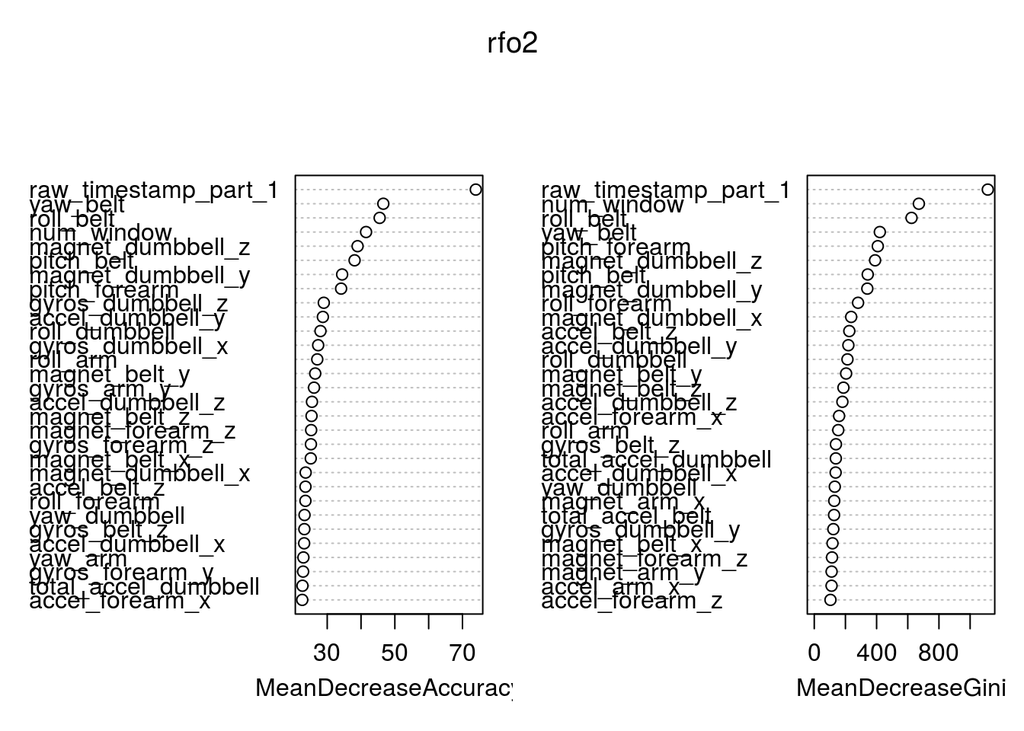

plot of importance measurement of variables in the model.

```r
varImpPlot( rfo2 )
```

## Testing the model with `train2` (40% of the trainning data)

Now we will test or model with the trainning data set that reprsenetn de 40% of the original trainning data set: `train2`.

```r
train2_prediction <- predict( rfo2, newdata = train2 )
kk                <- confusionMatrix( train2_prediction, myclasse[-casostest1] )
pander(kk$overall[1:2], caption = "overall." )
```

| Accuracy | Kappa |
| --- | --- |
| 0.9978 | 0.9973 |

```r
pander(kk$table       , caption = "Confusion table." )
```

Confusion table.

|  | A | B | C | D | E |
| --- | --- | --- | --- | --- | --- |
| **A** | 2232 | 7 | 0 | 0 | 0 |
| **B** | 0 | 1511 | 2 | 0 | 0 |
| **C** | 0 | 0 | 1366 | 1 | 0 |
| **D** | 0 | 0 | 0 | 1285 | 7 |
| **E** | 0 | 0 | 0 | 0 | 1435 |

```r
pander(t(kk$byClass)  , caption = "model parameters by class." )
```

model parameters by class.

|  | Class: A | Class: B | Class: C | Class: D | Class: E |
| --- | --- | --- | --- | --- | --- |
| **Sensitivity** | 1 | 0.9954 | 0.9985 | 0.9992 | 0.9951 |
| **Specificity** | 0.9988 | 0.9997 | 0.9998 | 0.9989 | 1 |
| **Pos Pred Value** | 0.9969 | 0.9987 | 0.9993 | 0.9946 | 1 |
| **Neg Pred Value** | 1 | 0.9989 | 0.9997 | 0.9998 | 0.9989 |
| **Prevalence** | 0.2845 | 0.1935 | 0.1744 | 0.1639 | 0.1838 |
| **Detection Rate** | 0.2845 | 0.1926 | 0.1741 | 0.1638 | 0.1829 |
| **Detection Prevalence** | 0.2854 | 0.1928 | 0.1742 | 0.1647 | 0.1829 |
| **Balanced Accuracy** | 0.9994 | 0.9975 | 0.9992 | 0.9991 | 0.9976 |

```r
# confusionMatrix(train2_prediction, myclasse[-casostest1])$overall['Accuracy']
```

We obtain a higth accuracy 0.998, so we may think that we have a goog model for prediction.

# Clasification of new cases

```r
testN_prediction <- predict(rfo2, newdata=testN)
pander(data.frame(test$user_name,testN_prediction))
```

| test.user_name | testN_prediction |
| --- | --- |
| pedro | B |
| jeremy | A |
| jeremy | B |
| adelmo | A |
| eurico | A |
| jeremy | E |
| jeremy | D |
| jeremy | B |
| carlitos | A |
| charles | A |
| carlitos | B |
| jeremy | C |
| eurico | B |
| jeremy | A |
| jeremy | E |
| eurico | E |
| pedro | A |
| carlitos | B |
| pedro | B |
| eurico | B |

R version 3.2.2 (2015-08-14) Platform: i686-pc-linux-gnu (32-bit) Running under: Ubuntu 15.10

locale: [1] LC_CTYPE=es_ES.UTF-8 LC_NUMERIC=C  
[3] LC_TIME=es_ES.UTF-8 LC_COLLATE=es_ES.UTF-8  
[5] LC_MONETARY=es_ES.UTF-8 LC_MESSAGES=es_ES.UTF-8  
[7] LC_PAPER=es_ES.UTF-8 LC_NAME=C  
[9] LC_ADDRESS=C LC_TELEPHONE=C  
[11] LC_MEASUREMENT=es_ES.UTF-8 LC_IDENTIFICATION=C

attached base packages: [1] stats graphics grDevices utils datasets methods base

other attached packages: [1] randomForest_4.6-12 xda_0.1 devtools_1.10.0  
[4] caret_6.0-68 ggplot2_2.0.0 lattice_0.20-33  
[7] pander_0.6.0

loaded via a namespace (and not attached): [1] codetools_0.2-14 digest_0.6.9 htmltools_0.3  
[4] minqa_1.2.4 splines_3.2.2 MatrixModels_0.4-1 [7] scales_0.3.0 grid_3.2.2 stringr_1.0.0  
[10] e1071_1.6-7 knitr_1.12.3 lme4_1.1-11  
[13] munsell_0.4.3 nnet_7.3-10 foreach_1.4.3  
[16] iterators_1.0.8 mgcv_1.8-7 Matrix_1.2-2  
[19] MASS_7.3-43 plyr_1.8.3 stats4_3.2.2  
[22] stringi_1.0-1 pbkrtest_0.4-5 magrittr_1.5  
[25] car_2.1-1 reshape2_1.4.1 rmarkdown_0.9.2  
[28] evaluate_0.8 gtable_0.1.2 colorspace_1.2-6  
[31] yaml_2.1.13 tools_3.2.2 parallel_3.2.2  
[34] nloptr_1.0.4 nlme_3.1-124 quantreg_5.19  
[37] class_7.3-13 formatR_1.2.1 memoise_1.0.0  
[40] Rcpp_0.12.3 SparseM_1.7